# Data Clean MedStar Data

Created: 2016-09-09 Updated: 2018-03-21

# Overview

In this file, we import the raw data files received from MedStar and do some basic data checks.

Specifically we import the following two files:

1. **DETECT_DATA_PIVOT.xlsx** - Data from MedStar that contains all uses of the DETECT screening tool.
2. **DETECT-Patient-Data_2017-07-19_144931.xlsx** - Data from MedStar that includes demographic and health information for all patients who where age >= 65 and treated during the pilot period.

# Key variable definitions

It’s important to understand the meaning of patient identification variables in the data, and the relationship between patient identification variables across both datasets. The following diagram shows how people are identified in the MedStar data:

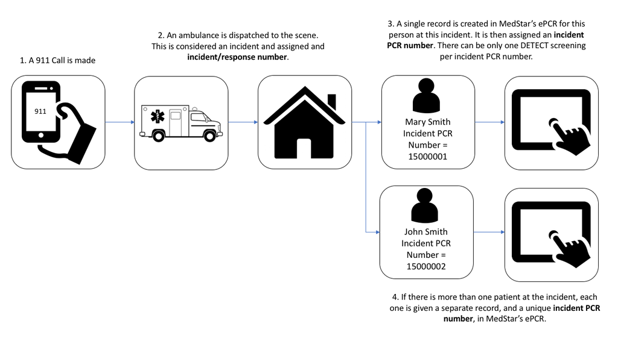

However, after manually checking the datasets we found that the terms “Incident” and “Response” are used inconsistently between files.

- In **DETECT_DATA_PIVOT.xlsx**:
  - **Response number** is unique to the incident/respnse (#2 in the diagram). In cases where there was more than one person screened at an incident/response, the response number is not unique to the person/screening (#3 and #4 in the diagram). This number matches response number in DETECT-Patient-Data_2017-07-19_144931.xlsx.
  - **Response date** is the date that MedStar ran the 911 call and filled out the DETECT screening tool.
- In **DETECT-Patient-Data_2017-07-19_144931.xlsx**:
  - **Date entered** is the date that MedStar ran the 911 call and filled out the DETECT screening tool.
  - **Incident call number** is unique to the incident/respnse (#2 in the diagram). In cases where there was more than one person screened at an incident/response, the response number is not unique to the person/screening (#3 and #4 in the diagram). This number matches response number in DETECT_DATA_PIVOT.xlsx.
  - **Incident PCR number** is unique to the person/DETECT screening at a given incident/response. Below, we add this number to DETECT_DATA_PIVOT.xlsx. NOTE: No two people should have the same incident PCR number; however, a single person may have multiple incident PCR numbers if they were treated by MedStar on multiple occasions.

In order to be consistent and reduce confusion, after importing the data below, we will use the terminology from DETECT-Patient-Data_2017-07-19_144931.xlsx.

# Table of contents

```r
library(tidyverse)
library(feather)
library(readxl)
library(stringr)
library(lubridate)
library(bfuncs)
```

# Import and clean DETECT response data

```r
col_info <- c(
  # "col_name",             "col_type"
  "response_num",           "text",
  "response_date",          "date",
  "aps_report_num",         "text",
  "full_name",              "text",
  "address",                "text",
  "city",                   "text",
  "state",                  "text",
  "zip",                    "text",
  "dob",                    "date",
  "age",                    "numeric",
  "unusual_odor36",         "text",
  "no_utils37",             "text",
  "hoarding38",             "text",
  "safe_env39",             "text",
  "alc_containers40",       "text",
  "cg_lack_know41",         "text",
  "cg_unengaged42",         "text",
  "cg_frustrated43",        "text",
  "cg_overwhelmed44",       "text",
  "cg_too_conerned45",      "text",
  "cg_deceptive46",         "text",
  "cg_bad_info47",          "text",
  "cg_alcdrugs48",          "text",
  "cg_dependent49",         "text",
  "socsup50",               "text",
  "no_talk51",              "text",
  "isolated52",             "text",
  "suspicious_injuries53",  "text",
  "old_injuries54",         "text",
  "alcdrugs55",             "text",
  "emo_distress56",         "text",
  "poor_hygiene57",         "text",
  "clothing58",             "text",
  "taking_meds59",          "text",
  "saving_meds60",          "text",
  "adls61",                 "text")
# Import data
medstar_detect <- read_excel(
  path = "/Users/bradcannell/Desktop/DETECT_DATA_PIVOT.xlsx",
  col_names = col_info[seq(1, length(col_info), 2)],
  col_types = col_info[seq(2, length(col_info), 2)],
  skip = 1)
rm(col_info)
about_data(medstar_detect) # 1,248 observations and 36 variables in the data
```

```
[1] "1,248 observations and 36 variables"
```

## Check for duplicate rows

First, check for entire duplicate rows

```r
medstar_detect %>%
  group_by_all() %>%
  filter(n() > 1) %>%
  count() %>%
  ungroup() %>%
  select(n)
```

| n |
| --- |
| 2 |

151003… Appears to have a duplicate row. Will drop.

```r
medstar_detect <- medstar_detect %>%
  group_by_all() %>%
  mutate(
    count = row_number(), # Counts rows by group
    dup   = count > 1     # TRUE if there is more than one row per group
  ) %>%
  filter(!dup) %>%
  select(-count, -dup)
about_data(medstar_detect) # 1,247 observations and 36 variables
```

```
[1] "1,247 observations and 36 variables"
```

## Check for duplicate response numbers

```r
medstar_detect %>%
  group_by(response_num) %>%
  filter(n() > 1) %>%
  count() %>%
  ungroup() %>%
  select(n) # 2 sets of duplicates (4 rows)
```

| n |
| --- |
| 2 |
| 2 |

151011… Includes information about two people. A man and a woman with the same last name. Both over age 65. Keep both rows because they are not duplicates of each other. They are two separate screenings that occurred at a single 911 response.

151024… Includes information about two people. A man and a woman with the same last name. Both over age 65. Keep both rows because they are not duplicates of each other. They are two separate screenings that occurred at a single 911 response.

```r
about_data(medstar_detect) # "1,247 observations and 36 variables"
```

```
[1] "1,247 observations and 36 variables"
```

## Separate name, address, and date of birth into multiple fields

```r
medstar_detect <- medstar_detect %>%
  mutate(
    first_name = str_extract(full_name, "^\\S*"),
    last_name = str_extract(full_name, "\\S*$"),
    birth_mnth = month(dob),
    birth_day  = day(dob),
    birth_year = year(dob),
    address_num = str_extract(address, "^\\d{1,5}"),
    address_street = str_trim(str_replace(address, "^\\d{1,5}", "")))
```

## Set all “NULL” values to NA

```r
medstar_detect <- medstar_detect %>%
  # Null to NA
  map_if(.p = is.character,
         .f = function(x) {
           x[x == "NULL"] <- NA
           return(x)}) %>%
  as_tibble()
```

## Coerce selected character vectors (screening questions) to factors

```r
medstar_detect <- medstar_detect %>%
  map_at(
    .at = c(11:36),  # Screening questions
    .f = factor) %>%
  as_tibble
```

## Check response id’s

Check to see if all the response id’s from the MedStar compliance data exist in the current data.

```r
response_ids <- feather::read_feather("/Users/bradcannell/Desktop/response_ids.feather")
```

```r
response_ids %>%
  anti_join(medstar_detect, by = "response_num") %>%  # 6 response numbers
  unique()
```

There are 6 responses id’s in the MedStar compliance data that don’t appear in the MedStar DETECT screening items data (results hidden to protect participant privacy). I have an email from MedStar from 2016-10-10 outlining the discrepancy. One response id had all nulls for the DETECT screening items. One response id could not be found in the query. The rest were ineligible for the DETECT screening tool because of age.

At this point, there should be 8 response id’s from the compliance data that have a match in the DETECT screening tool data (results hidden to protect participant privacy).

```r
response_ids %>%
  semi_join(medstar_detect, by = "response_num") %>%  # 8 response numbers
  unique()
```

## Add a dataset identifier tag

Adding a variable that will allow me to tell which rows had a DETECT screening tool use (even if all NA) after I merge this data with the demographics data below.

```r
medstar_detect$detect_data <- 1
```

## Count rows, unique responses, and unique people

```r
medstar_detect %>%
  mutate(person = paste(full_name, dob)) %>%
  group_by(response_num, full_name) %>%
  mutate(response_names = paste(response_num, full_name)) %>%
  ungroup() %>%
  summarise(
    `Total Rows` = n() %>% format(big.mark = ","),
    `Unique 911 Responses` = unique(response_num) %>% length() %>% format(big.mark = ","),
    `Unique Response And Name` = unique(response_names) %>% length() %>% format(big.mark = ","),
    `Unique People` = unique(person) %>% length() %>% format(big.mark = ",")
  )
```

| Total Rows | Unique 911 Responses | Unique Response And Name | Unique People |
| --- | --- | --- | --- |
| 1,247 | 1,245 | 1,247 | 1,141 |

So, the MedStar detect screening data contains 1,247 total rows of data that correspond to 1,245 911 responses, 1,247 unique response/name combinations, and 1,141 unique people (assuming first name, last name, and age uniquely identifies people in this data).

## Rename response number

In order to be consistent and reduce confusion, we will use the terminology from DETECT-Patient-Data_2017-07-19_144931.xlsx.

```r
medstar_detect <- medstar_detect %>% rename(incident_call_number = response_num)
about_data(medstar_detect) # 1,247 observations and 44 variables
```

```
[1] "1,247 observations and 44 variables"
```

top

# Import MedStar data containing the patient demographic and health information

```r
col_info <- c(
  # "col_name",           "col_type"
  "date_entered",         "date",
  "incident_call_number", "text",
  "incident_pcr_number",  "text",
  "first_name",           "text",
  "last_name",            "text",
  "age",                  "numeric",
  "gender",               "text",
  "race",                 "text",
  "chief_complaint",      "text",
  "primary_impression",   "text",
  "primary_symptom",      "text",
  "other_symptom",        "text",
  "drug_use",             "text",
  "crew_member_id",       "text",
  "medical_surgery_hist", "text",
  "current_meds",         "text")
# Import data
medstar_demo <- read_excel(
  path = "/Users/bradcannell/Desktop/DETECT-Patient-Data_2017-07-19_144931.xlsx",
  col_names = col_info[seq(1, length(col_info), 2)],
  col_types = col_info[seq(2, length(col_info), 2)],
  skip = 1)
rm(col_info)
about_data(medstar_demo) # 99,724 observations and 16 variables
```

```
[1] "99,724 observations and 16 variables"
```

## Grab just the first part of two-part first names

```r
medstar_demo <- medstar_demo %>%
  mutate(first_name = str_extract(first_name, "^\\S*"))
```

## Check for duplicate rows

First, check for rows that are entirely duplicated

```r
order_all_cols <- names(medstar_demo) %>% rlang::syms()
medstar_demo %>%
  arrange(!!!order_all_cols) %>%
  group_by_all() %>%
  filter(n() > 1) %>%
  count() %>%
  ungroup() %>%
  select(n) # 387 groups of duplicates
```

| n |
| --- |
| 2 |
| 2 |
| 2 |
| 2 |
| 2 |
| 2 |
| 2 |
| 2 |
| 2 |
| 2 |

[output cut: 377 more lines]

I manually inspected the duplicate rows. They appear to be genuine duplicates. Below I will drop the duplicate rows.

```r
rm(order_all_cols)
```

```r
medstar_demo <- medstar_demo %>%
  group_by_all() %>%
  mutate(
    count = row_number(), # Counts rows by group
    dup   = count > 1     # TRUE if there is more than one row per group
  ) %>%
  ungroup() %>%
  filter(!dup) %>%
  select(-count, -dup)
about_data(medstar_demo) # 99,311 observations and 16 variables
```

```
[1] "99,311 observations and 16 variables"
```

## Check for incident PCR numbers that correspond to more than one person

NOTE: No two people should have the same incident PCR number; however, a single person may have multiple incident PCR numbers if they were treated by MedStar on multiple occasions.

NOTE: There are multiple rows in this data for each person. Those rows that are complete duplicates were already dropped above. Because our purpose is just to see if there are any instances were a incident PCR number corresponds to more than one name, we are just going to keep one row per combination of incident PCR number and first name.

```r
medstar_demo %>%
  group_by(incident_pcr_number, first_name) %>%
  mutate(count = row_number()) %>%
  filter(count == 1) %>% # 2,018 rows
  ungroup() %>%
  summarise(
    `Rows grouped by PCR and Name` = n(),
    `Unique PCR numbers` = unique(incident_pcr_number) %>% length()
  )
```

| Rows grouped by PCR and Name | Unique PCR numbers |
| --- | --- |
| 2018 | 2018 |

## Count rows, unique responses, and unique people

```r
medstar_demo %>%
  mutate(person = paste(first_name, last_name, age, sep = "_")) %>%
  group_by(incident_call_number, first_name) %>%
  mutate(incident_names = paste(incident_call_number, first_name, sep = "_")) %>%
  ungroup() %>%
  summarise(
    `Total Rows` = n() %>% format(big.mark = ","),
    `Unique Incidents` = unique(incident_call_number) %>% length() %>% format(big.mark = ","),
    `Unique PCR` = unique(incident_pcr_number) %>% length() %>% format(big.mark = ","),
    `Unique Incident And Name` = unique(incident_names) %>% length() %>% format(big.mark = ","),
    `Unique People` = unique(person) %>% length() %>% format(big.mark = ",")
  )
```

| Total Rows | Unique Incidents | Unique PCR | Unique Incident And Name | Unique People |
| --- | --- | --- | --- | --- |
| 99,311 | 2,011 | 2,018 | 2,014 | 1,776 |

So, the MedStar demographics and health data contains 99,311 total rows of data that correspond to 2,011 911 responses, 2,018 incident PCR numbers, 2,014 unique response/name combinations, and 1,776 unique people (assuming first name, last name, and age uniquely identifies people in this data).